# Differential Expression (B6 mm10 STAR)

Nastassia Gobet, Maxime Jan

14 October 2019 -

# GOAL

Perform the differential gene expression in liver and cortex.

# Packages

```r
# loading needed pacakges
library(knitr)
##if (!requireNamespace("BiocManager"))
##  install.packages("BiocManager")
##BiocManager::install()
##BiocManager::install(c('edgeR', 'DESeq'))
library(edgeR)
```

```r
library(limma)
library(vioplot)
```

# DATA

## gene expression table

The input data are raw counts of gene expression (counted by ht-count). Rows are genes and columns are libraries/samples. (One library per sample, no replicate except for parental lines).

```r
# Import the raw counts table for liver
countsLiver <- read.delim('F:/BXD/data/transcriptome/3_counting_htseq/B6mm10/count_B6mm10_liver.txt', header=TRUE, row.names=1, stringsAsFactors=TRUE, sep="\t")
# Import the raw counts table for cortex
countsCortex <- read.delim('F:/BXD/data/transcriptome/3_counting_htseq/B6mm10/count_B6mm10_cortex.txt', header=TRUE, row.names=1, stringsAsFactors=TRUE, sep="\t")

# load B6 mm10 geneID to gene name convert table
B6mm10geneConvert <- read.table("F:/BXD/references/gene_names_B6mm10.tab", header=FALSE, stringsAsFactors=FALSE, sep=" ")
colnames(B6mm10geneConvert) <- c("GeneID", "GeneName")
# remove B6 replicate gene names
B6mm10geneConvert <- B6mm10geneConvert[-which(duplicated(B6mm10geneConvert$GeneName)),]
rownames(B6mm10geneConvert) <- 1:nrow(B6mm10geneConvert)
### could be improved by adding the counts from different transcripts

# try to find B6 matching names
idx <- na.omit(match(rownames(countsCortex),B6mm10geneConvert$GeneID))
# take B6 subset
countsCortex <- countsCortex[B6mm10geneConvert$GeneID[idx],]
countsLiver <- countsLiver[B6mm10geneConvert$GeneID[idx],]
# convert B6 rownames (GeneID) into gene name
rownames(countsCortex) <- B6mm10geneConvert$GeneName[idx]
rownames(countsLiver) <- B6mm10geneConvert$GeneName[idx]

dim(countsCortex)
```

```
## [1] 54429    86
```

```r
dim(countsLiver)
```

```
## [1] 54429    86
```

```r
# convert GSM names into biologically meaning names
# load table for conversion
sratable <- read.table("F:/BXD/data/transcriptome/RNAseq/SraRunTable.txt", header=TRUE, stringsAsFactors=FALSE, sep="\t")
idxC <- match(colnames(countsCortex),sratable$Sample_Name)
idxL <- match(colnames(countsLiver),sratable$Sample_Name)

colnames(countsCortex) <- paste(sratable$genotype[idxC], sratable$condition[idxC], sep="_")
colnames(countsLiver) <- paste(sratable$genotype[idxL], sratable$condition[idxL], sep="_")
```

# Analysis

## Filtering

We want to filter the expression data to take only gene with average expression above 10. This is an arbitrary threshold to remove genes that are too noisy.

```r
# create a subset of the count table, filtering out rows (genes) with average counts <= 10
countsLiver <- countsLiver[which(apply(countsLiver, MARGIN=1, FUN=mean)>10),]
countsCortex <- countsCortex[which(apply(countsCortex, MARGIN=1, FUN=mean)>10),]

dim(countsCortex)
```

```
## [1] 16997    86
```

```r
dim(countsLiver)
```

```
## [1] 13274    86
```

## Standarization

The normalization is performed using the Weigthed trimmed mean of M-values (TMM) method of the edgeR package. This step standarizes the counts gene expression to take into account the variation in library size (=number of counts per library), the variation in length of the transcripts, and in RNA population variation. (Robinson, Genome Biology, 2010).

```r
# formatting for edgeR (creates a DGEList object from the dataframe)
dL <- DGEList(counts=countsLiver)
```

```
## Repeated column names found in count matrix
```

```r
dC <- DGEList(counts=countsCortex)
```

```
## Repeated column names found in count matrix
```

```r
# calculate the normalization factors for each sample
dL <- calcNormFactors(dL, method="TMM")
dC <- calcNormFactors(dC, method="TMM")
### what sample is the reference for the normalisation factor?

# check the distribution of the normalisation factors
vioplot(dL$samples$norm.factors, col="white", horizontal=TRUE, names="")
```

```
## [1] 0.8947099 1.1304035
```

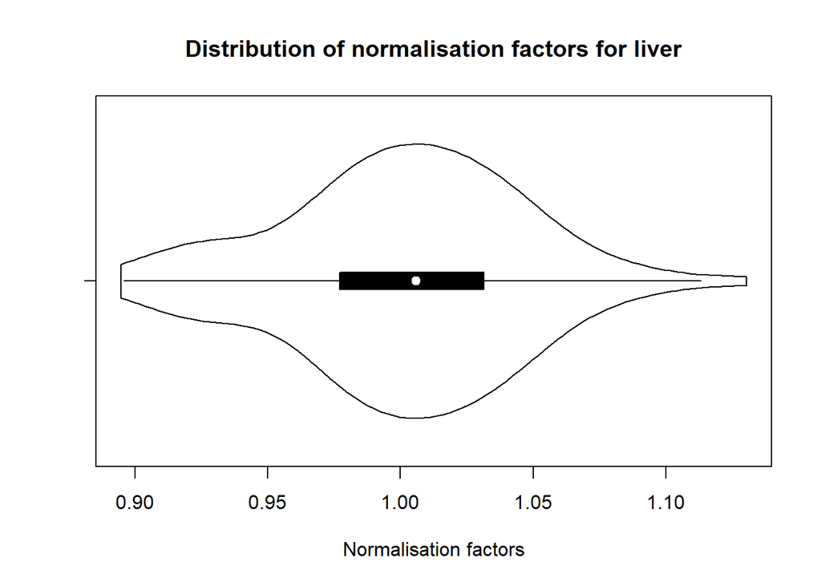

```r
title(main="Distribution of normalisation factors for liver", xlab="Normalisation factors")
```

```r
vioplot(dC$samples$norm.factors, col="white", horizontal=TRUE, names="")
```

```
## [1] 0.9686253 1.0431282
```

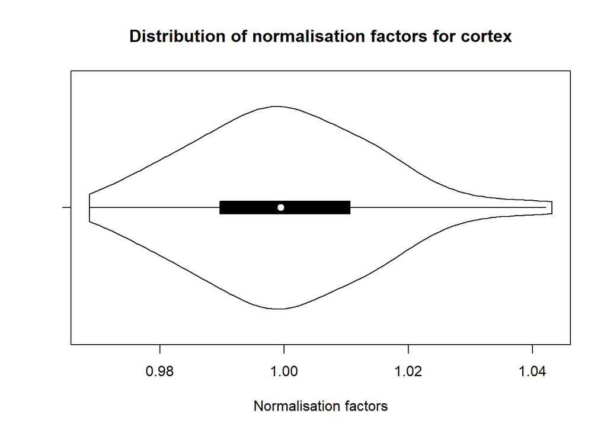

```r
title(main="Distribution of normalisation factors for cortex", xlab="Normalisation factors")
```

```r
# calculate CPM and normalize the counts
normalizedCPMcountsL <- data.frame(cpm(dL, normalized.lib.sizes=TRUE))
normalizedCPMcountsC <- data.frame(cpm(dC, normalized.lib.sizes=TRUE))

# Export normalized CPM
write.table(normalizedCPMcountsL, file="edgeR_normalized_CPM_Liver.tab", row.names=TRUE, sep="\t", quote=FALSE)
write.table(normalizedCPMcountsC, file="edgeR_normalized_CPM_Cortex.tab", row.names=TRUE, sep="\t", quote=FALSE)
```

## Differential gene expression

Find which genes are up or down regulated by SD treatment (SD vs NSD).

This is done here using functions from limma package:

- model.matrix creates a model matrix (also called design matrix) which describes which samples are compared, in a voom-friendly format.
- voom prepares the data to DE analysis by considering different variances for different samples/libraries (=observations) & genes. The step are: log2CPM transformation, estimate mean-variance relationship, estimate.
- lmFit fits linear model (a line with slope and intercept) for each gene. It uses least squares fitting method (method=“ls”).
- eBayes computes statistics by empirical Bayes moderation (moderated t-statistics, moderated F-statistic, B is the log-odds). The goal is to rank genes from the more to the less differentially expressed.
- toptable extracts top ranked genes from a fit.

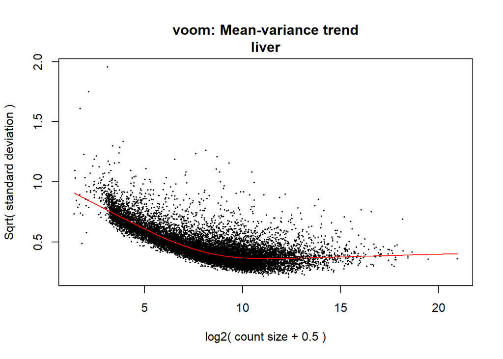

```r
# design
##all(colnames(countsCortex)==colnames(countsLiver))
variables <- matrix(unlist(strsplit(colnames(countsCortex),"_")), nrow=2)
conds <- factor(variables[2,])
strain <- factor(variables[1,])
# create the design matrix by paired samples
design <- model.matrix(~strain+conds)

# by default the normalization method is quantile (voom calls normalizeBetweenArrays), here TMM factors computed before are used.
# plot the mean-variance trend
resLiver <- voom(dL, design, plot=TRUE)
title(main="liver", line=0.5)
```

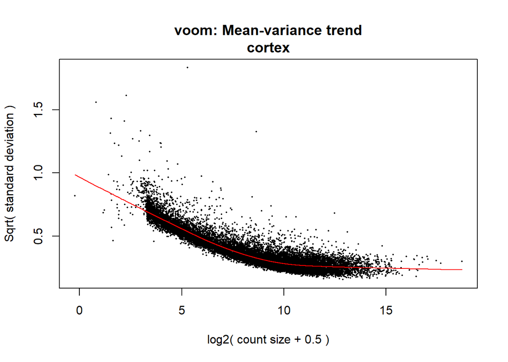

```r
resCortex <- voom(dC, design, plot=TRUE)
title(main="cortex", line=0.5)
```

```r
# fitting
# fit the linear models (one model per gene)
fitL <- lmFit(resLiver, design)
fitC <- lmFit(resCortex, design)
# calculate the t-statistics using empirical Bayes moderation to determine if each gene is differentially expressed.
fitL2 <- eBayes(fitL)
fitC2 <- eBayes(fitC)

# retrieve stats for each gene from the fitted models. The maximum number of genes is set higher than the number of genes tested so that all genes are taken. P-values are adjusted by FDR method, and sorted by log-odds (B)
resultTableL <- topTable(fitL2, coef="condsSleep Deprived", adjust.method="fdr", sort.by="B", number=1000000)
resultTableC <- topTable(fitC2, coef="condsSleep Deprived", adjust.method="fdr", sort.by="B", number=1000000)

# store information about DE analysis
write.table(resultTableL, file="RNA_SD_vs_NSD_DiffExp_Limma_Liver.txt", row.names=TRUE, sep="\t", quote=FALSE)
write.table(resultTableC, file="RNA_SD_vs_NSD_DiffExp_Limma_Cortex.txt", row.names=TRUE, sep="\t", quote=FALSE)
```

# Plotting results

Volcano plots

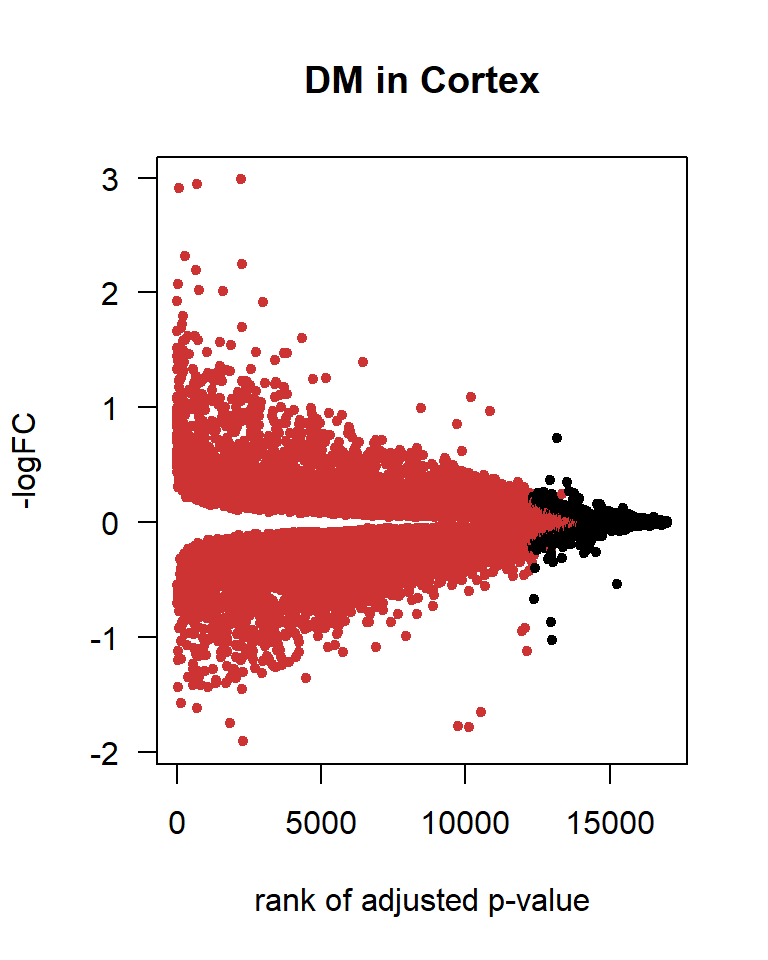

```r
# load table with results of differential expression
DEdata_Cortex <- read.table('RNA_SD_vs_NSD_DiffExp_Limma_Cortex.txt', sep="\t")
DEdata_Liver <- read.table('RNA_SD_vs_NSD_DiffExp_Limma_Liver.txt', sep="\t")

# volcano plot all transcripts in black and significant in red
# set the colors
palette(c("black", "brown3"))

# plot for Cortex
plot(1:nrow(DEdata_Cortex), DEdata_Cortex$logFC, las=1, pch=20, col=as.factor(DEdata_Cortex$adj.P.Val<=0.05),
       main="DM in Cortex", xlab="rank of adjusted p-value", ylab="-logFC")
```

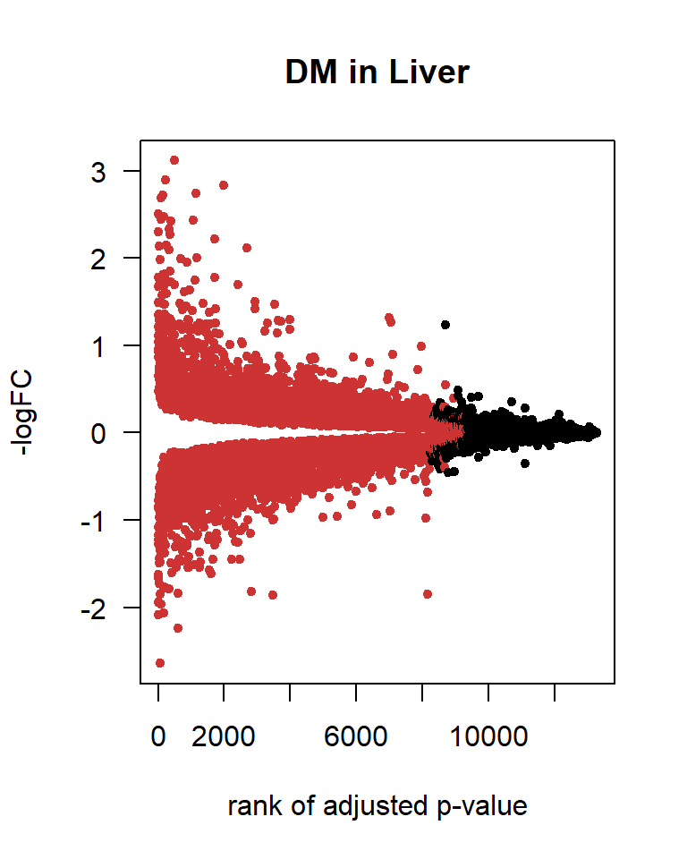

```r
# plot for Liver
plot(1:nrow(DEdata_Liver), DEdata_Liver$logFC, las=1, pch=20, col=as.factor(DEdata_Liver$adj.P.Val<=0.05),
       main="DM in Liver", xlab="rank of adjusted p-value", ylab="-logFC")
```

The logFC column represents ratio of SD over NSD (positive values are up-regulated by SD, negative values are down-regulated by SD).

77% of genes are significantly (below or equal to 0.05) differentially expressed in cortex, and 67% in liver.

```r
# get top 5 up- and top 5 down-regulated genes
DEdata_Cortex <- DEdata_Cortex[order(DEdata_Cortex$logFC),]
head(DEdata_Cortex,5)
```

```
##                   logFC   AveExpr          t      P.Value    adj.P.Val
## Gm11738       -1.907835 -1.778106 -14.131340 1.750361e-19 1.416709e-18
## Gm28439       -1.785691 -2.919593  -3.691547 5.332137e-04 8.509891e-04
## Gh            -1.773444 -2.541503  -4.036560 1.780355e-04 2.983407e-04
## 1700093K21Rik -1.751436 -1.571270 -15.557936 2.971109e-21 3.130809e-20
## Slc6a5        -1.656785 -3.324903  -3.344906 1.529510e-03 2.326153e-03
##                        B
## Gm11738       31.9198996
## Gm28439       -0.2639758
## Gh             0.5962818
## 1700093K21Rik 35.7538185
## Slc6a5        -1.1808445
```

```r
print(head(DEdata_Cortex[,c("logFC","adj.P.Val")],5))
```

```
##                   logFC    adj.P.Val
## Gm11738       -1.907835 1.416709e-18
## Gm28439       -1.785691 8.509891e-04
## Gh            -1.773444 2.983407e-04
## 1700093K21Rik -1.751436 3.130809e-20
## Slc6a5        -1.656785 2.326153e-03
```

```r
tail(DEdata_Cortex,5)
```

```
##                  logFC   AveExpr        t      P.Value    adj.P.Val
## Tekt4         2.244162 -1.157442 13.98177 2.722403e-19 2.151217e-18
## 1700016P03Rik 2.314850  2.357395 23.83914 9.744827e-30 5.633770e-28
## Arc           2.910260  7.648569 31.44534 1.296658e-35 3.148471e-33
## Plin4         2.948315  2.091787 20.04600 3.454130e-26 8.222667e-25
## Egr2          2.984680 -2.316525 14.95593 1.610572e-20 1.528884e-19
##                      B
## Tekt4         32.26356
## 1700016P03Rik 57.22752
## Arc           71.05879
## Plin4         49.21961
## Egr2          32.64705
```

```r
print(tail(DEdata_Cortex[,c("logFC","adj.P.Val")],5))
```

```
##                  logFC    adj.P.Val
## Tekt4         2.244162 2.151217e-18
## 1700016P03Rik 2.314850 5.633770e-28
## Arc           2.910260 3.148471e-33
## Plin4         2.948315 8.222667e-25
## Egr2          2.984680 1.528884e-19
```

```r
DEdata_Liver <- DEdata_Liver[order(DEdata_Liver$logFC),]
head(DEdata_Liver,5)
```

```
##                   logFC    AveExpr         t      P.Value    adj.P.Val
## Ripor2        -2.640307  0.9883728 -23.07299 3.135964e-28 7.854112e-26
## Nfe2          -2.236107  0.4661487 -13.58398 2.295589e-18 5.036636e-17
## Herc3         -2.080929  2.0215860 -30.50040 7.254297e-34 9.629354e-31
## 1700092C10Rik -2.066670 -1.1826706 -18.69617 3.785854e-24 3.514226e-22
## D130043K22Rik -1.966639  1.9415191 -20.47140 6.909197e-26 1.007832e-23
##                      B
## Ripor2        53.43124
## Nfe2          31.55558
## Herc3         66.41630
## 1700092C10Rik 43.08443
## D130043K22Rik 48.71669
```

```r
print(head(DEdata_Liver[,c("logFC","adj.P.Val")],5))
```

```
##                   logFC    adj.P.Val
## Ripor2        -2.640307 7.854112e-26
## Nfe2          -2.236107 5.036636e-17
## Herc3         -2.080929 9.629354e-31
## 1700092C10Rik -2.066670 3.514226e-22
## D130043K22Rik -1.966639 1.007832e-23
```

```r
tail(DEdata_Liver,5)
```

```
##            logFC    AveExpr         t      P.Value    adj.P.Val        B
## Gm15889 2.719974  0.5745934 18.465820 6.500614e-24 5.714514e-22 43.86717
## Fam107a 2.740195 -1.6822401 11.220806 3.100837e-15 3.585411e-14 24.16295
## Mt2     2.836509  3.2761263  9.054627 4.256265e-12 2.824883e-11 17.00224
## Ttll8   2.892332 -1.6340279 18.216617 1.173409e-23 9.439898e-22 41.51750
## Gm48199 3.115193 -2.1395216 14.714654 9.357383e-20 2.754100e-18 33.43318
```

```r
print(tail(DEdata_Liver[,c("logFC","adj.P.Val")],5))
```

```
##            logFC    adj.P.Val
## Gm15889 2.719974 5.714514e-22
## Fam107a 2.740195 3.585411e-14
## Mt2     2.836509 2.824883e-11
## Ttll8   2.892332 9.439898e-22
## Gm48199 3.115193 2.754100e-18
```

```r
# how many have a log fold change (absolute value) above 2?
length(which(abs(DEdata_Cortex$logFC)>2))
```

```
## [1] 9
```

```r
length(which(abs(DEdata_Liver$logFC)>2))
```

```
## [1] 24
```

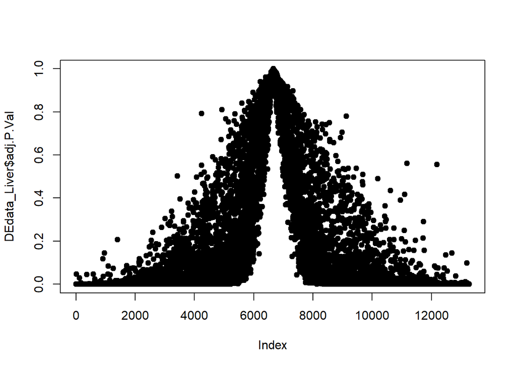

```r
# testing
plot(DEdata_Liver$adj.P.Val, pch=19)
```

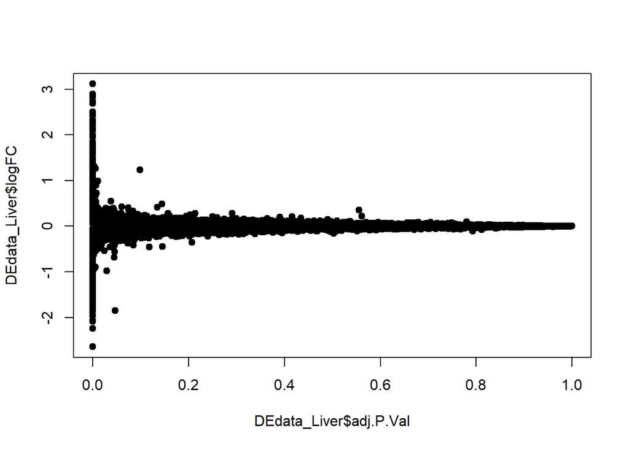

```r
plot(DEdata_Liver$adj.P.Val,DEdata_Liver$logFC, pch=19)
```

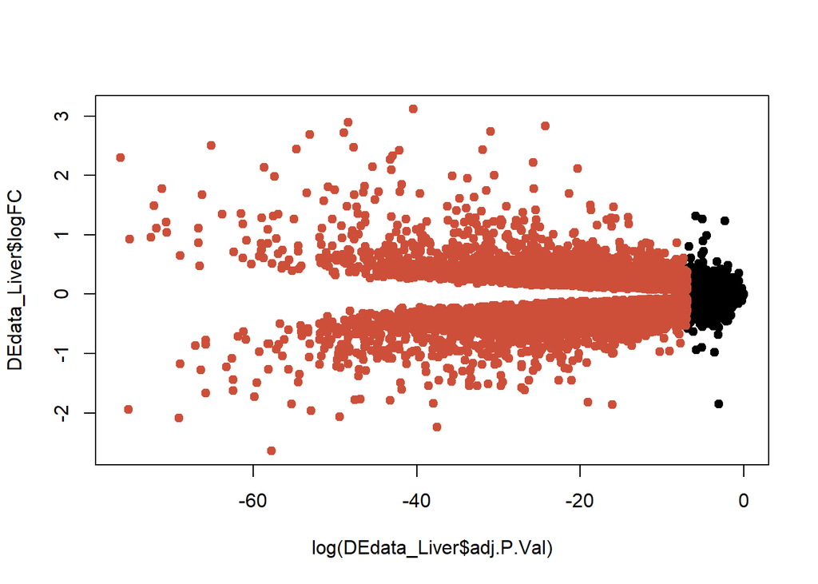

```r
plot(log(DEdata_Liver$adj.P.Val),DEdata_Liver$logFC, pch=19)
points(log(DEdata_Liver$adj.P.Val[abs(DEdata_Liver$adj.P.Val)<0.001]),DEdata_Liver$logFC[abs(DEdata_Liver$adj.P.Val)<0.001], pch=19, col="tomato3")
```